# Exercise 1

In this exercise, I take the data from VAST challenge, used the data collected from volunteers to evaluate the city’s demographics.

## Demographics

### Overall view of the 5 demographical features

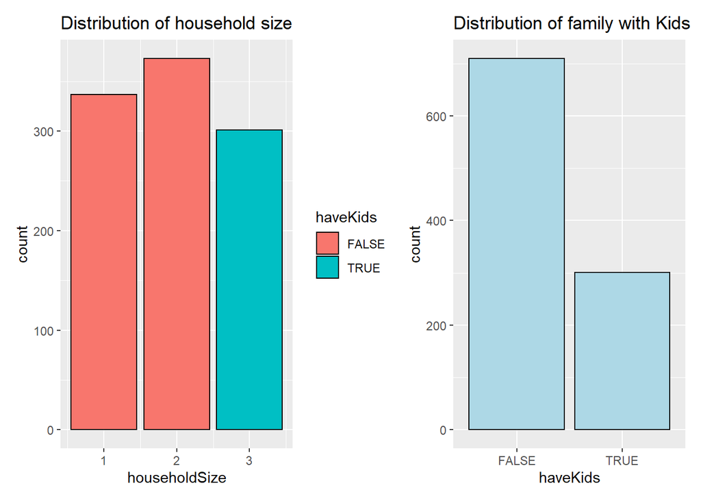

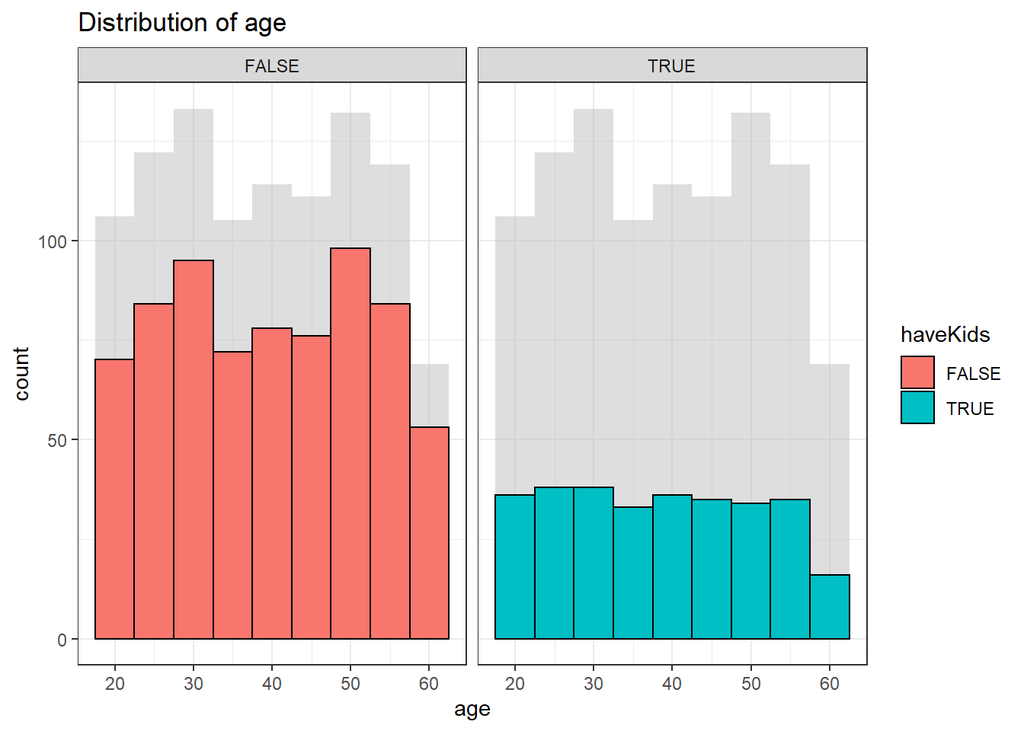

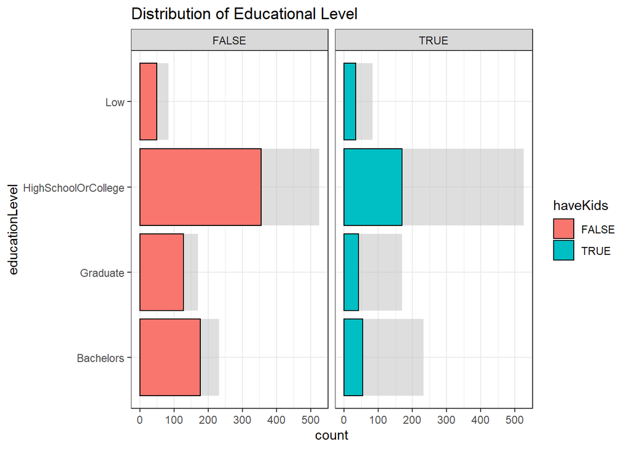

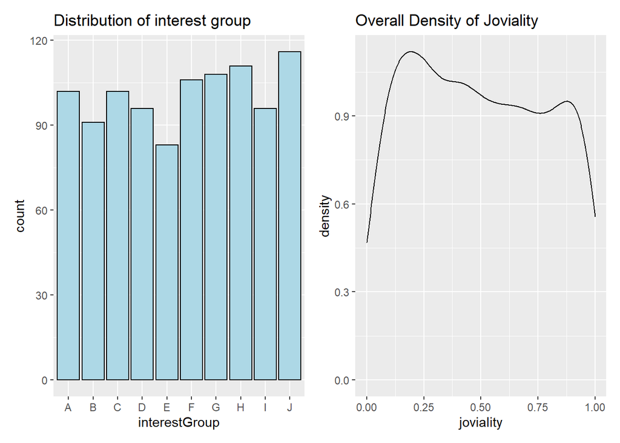

From the graphs we have following findings:  
1. Households of size 3 always have kids, household with kids is always of size 3, which cannot be normal.  
2. The distribution of age is quite even, the proportion of youngsters is big and healthy.  
3. Majority of volunteer have high school or college education level.  
4. Distribution of interest group is quite even.

### Detailed view of democraphical features

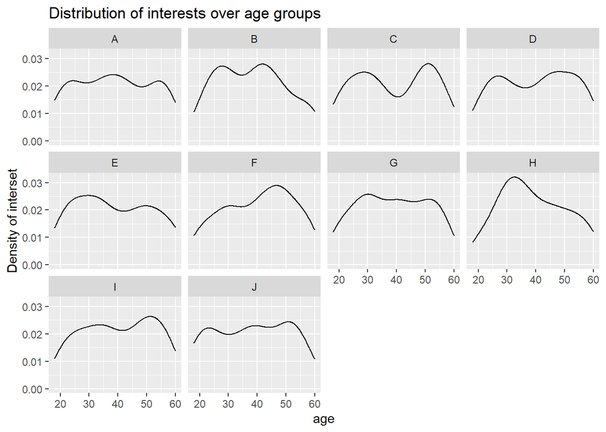

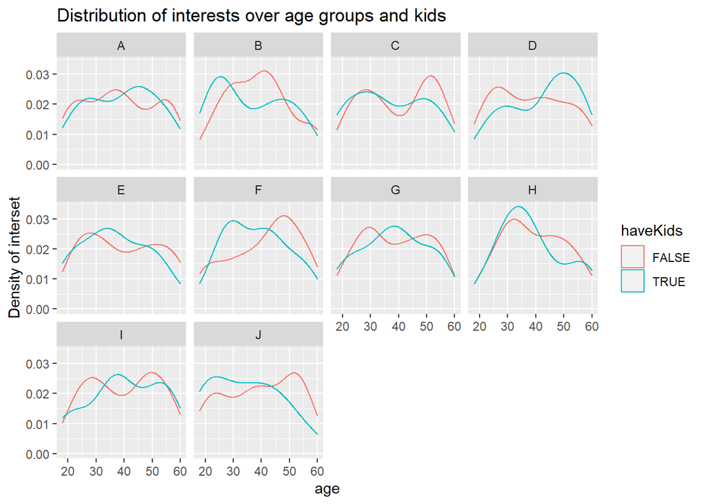

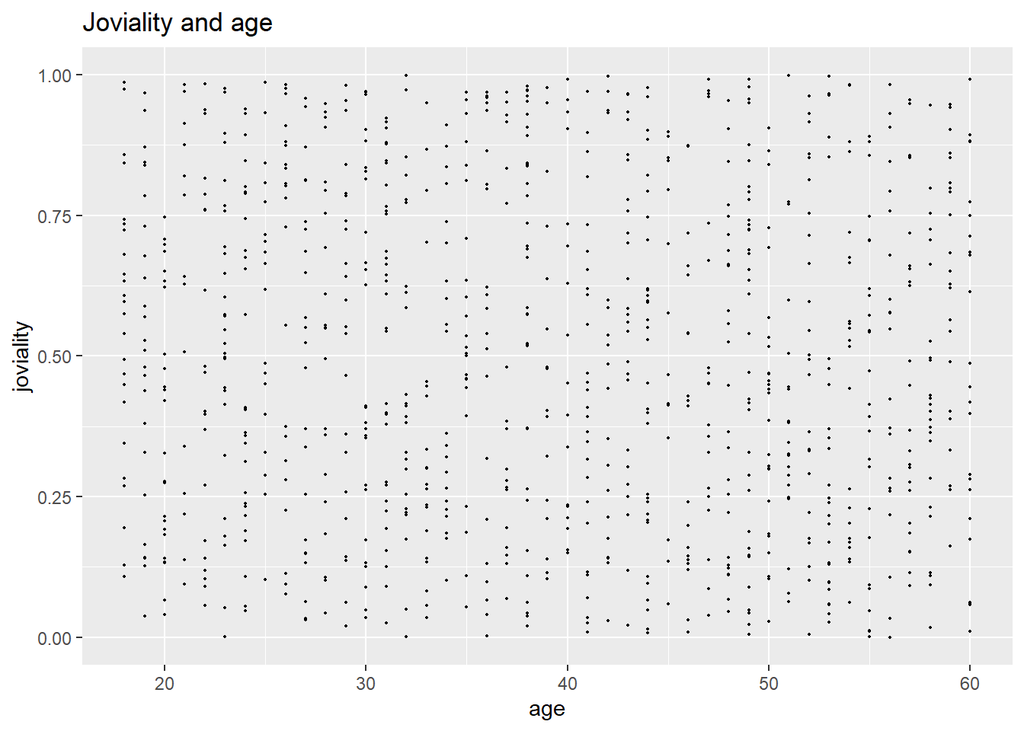

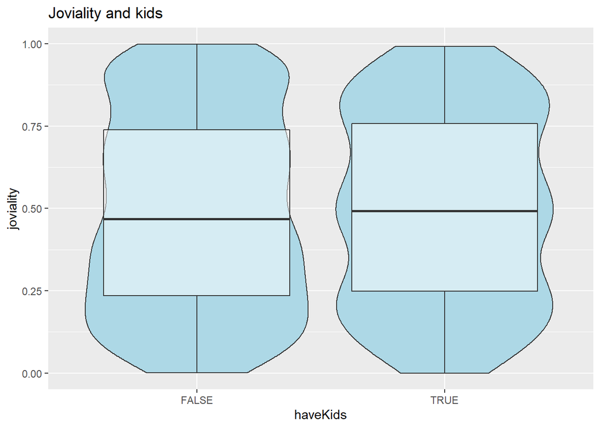

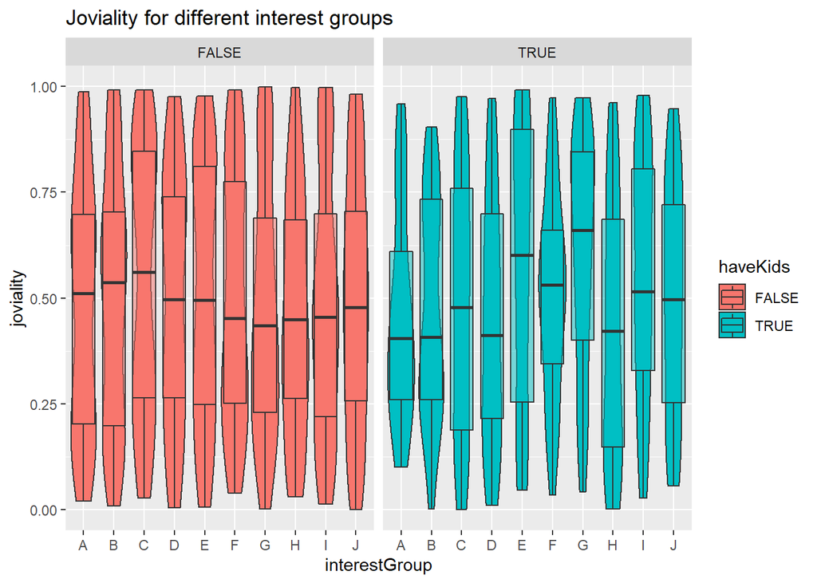

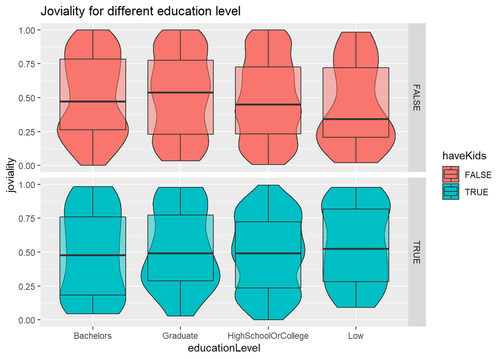

From the graphs we have following findings:  
1. The distribution of interest varies for different age groups, it also changes with regards of the presence of kids.  
2. People with kids have slightly higher joviality level compared with those who don’t.  
3. People from interest group and with kids have the highest average joviality level.  
4. People with low education level and no kids have the lowest joviality level.  
5. There is no relationship between joviality and age.